# CONGRESO

Informe Institucional de Resultados Caracterización Cuestionarios Perfeccionismo y Tenacidad

Psic. Ma. Fernanda Serrano García

2024-05-08

# USAGE DOCUMENTATION

## TABLES EXAMPLES

To show a level-percentage table by school:

The elements of the list

- First element:

[1] “andes” “bicentenario” “cepac” “coltec”

[5] “diosa” “esperanza” “pidahi” “primcongreso”

[9] “secaugusto” “villavicencio”

- Second element:

[1] “fG_level” “tenacidad_level” “esfuerzo_level”

[4] “preocupacion_level”

### Table Augusto Intelligence

- Use “caption” field to modify the title.

Nivel de Inteligencia

| grado | bajo | medio-bajo | medio | medio-alto | alto | Muy_bajo | muy_alto |
| --- | --- | --- | --- | --- | --- | --- | --- |
| 6a | 23.8 | 33.3 | 28.6 | 9.5 | 4.8 | NA | NA |
| 6b | 6.2 | 18.8 | 68.8 | 6.2 | NA | NA | NA |
| 6c | 15.8 | 10.5 | 31.6 | 21.1 | 5.3 | 10.5 | 5.3 |
| 6d | 20.0 | 24.0 | 32.0 | 16.0 | 8.0 | NA | NA |

### Table Augusto Tenacidad

- Use “caption” field to modify the title.

Nivel de Tenacidad

| grado | Bajo | Medio | Alto |
| --- | --- | --- | --- |
| 6a | 61.9 | 28.6 | 9.5 |
| 6b | 56.2 | 31.2 | 12.5 |
| 6c | 63.2 | 26.3 | 10.5 |
| 6d | 40.0 | 32.0 | 28.0 |

### Table Augusto Esfuerzo

- Use “caption” field to modify the title.

Nivel de Esfuerzo

| grado | Bajo | Medio | Alto | Superior |
| --- | --- | --- | --- | --- |
| 6a | 38.1 | 38.1 | 14.3 | 9.5 |
| 6b | 25.0 | 18.8 | 43.8 | 12.5 |
| 6c | 42.1 | 10.5 | 31.6 | 15.8 |
| 6d | 12.0 | 44.0 | 28.0 | 16.0 |

### Table Augusto Preocupacion

- Use “caption” field to modify the title.

Nivel de Preocupacion

| grado | Bajo | Medio | Alto | Superior |
| --- | --- | --- | --- | --- |
| 6a | 28.6 | 38.1 | 19.0 | 14.3 |
| 6b | 25.0 | 43.8 | 25.0 | 6.2 |
| 6c | 36.8 | 15.8 | 26.3 | 21.1 |
| 6d | 28.0 | 20.0 | 28.0 | 24.0 |

## Showing a mean-sd table by school

Note that there is only one mean-sd table by school

### Mean and Standard deviation Table for Augusto

- Use “caption” field to modify the title.

primcongreso

| grado | fG P | fG d | Tenacidad P | Tenacidad d | Esfuerzo P | Esfuerzo d | Preocupacion P | Preocupacion d |
| --- | --- | --- | --- | --- | --- | --- | --- | --- |
| 6a | 94.0 | 11.4 | 2.7 | 0.6 | 43.4 | 6.4 | 57.9 | 13.3 |
| 6b | 97.2 | 7.5 | 3.0 | 0.5 | 46.4 | 7.2 | 58.5 | 12.0 |
| 6c | 95.5 | 18.2 | 2.7 | 0.7 | 44.1 | 10.6 | 60.9 | 20.0 |
| 6d | 96.9 | 12.7 | 3.2 | 0.6 | 46.4 | 8.4 | 63.8 | 19.9 |

## GRAPHICS EXAMPLES

Showing a level-percentage graphic:

Use the same elements as the level-percent table, but set ‘graph’ in the last element.

### Percent-Levels Augusto Intelligence

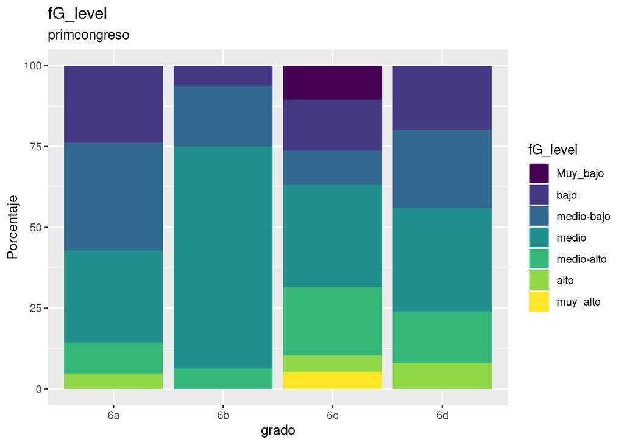

### Percent-Levels Augusto Tenacity

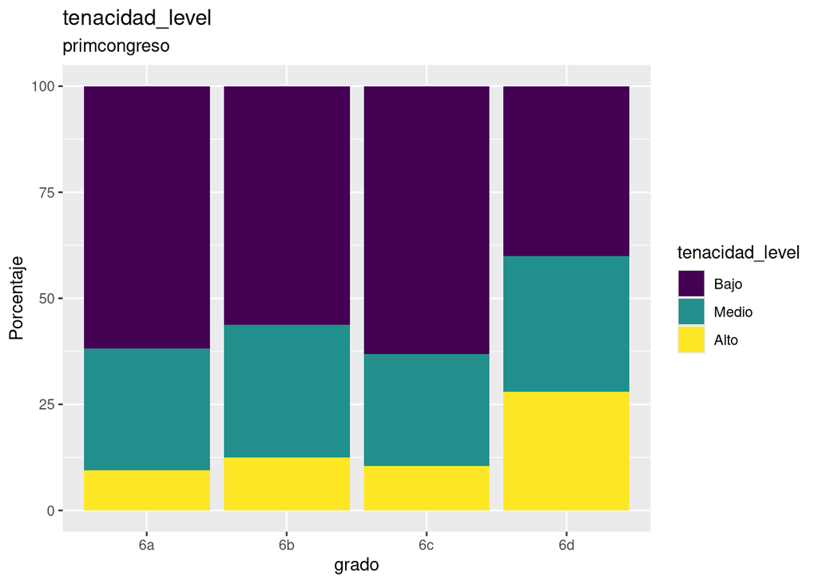

### Percent-Levels Augusto Effort

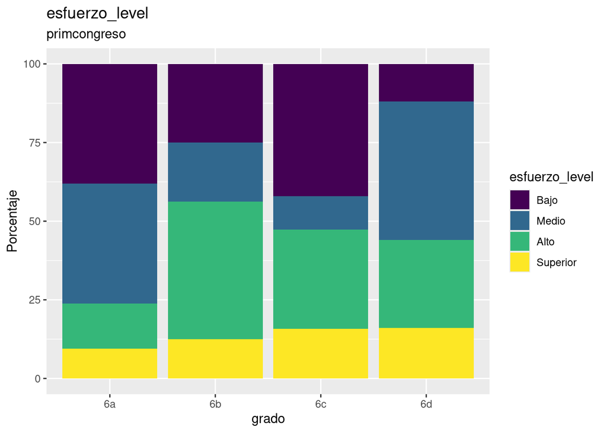

### Percent-Levels Augusto Preoccupation

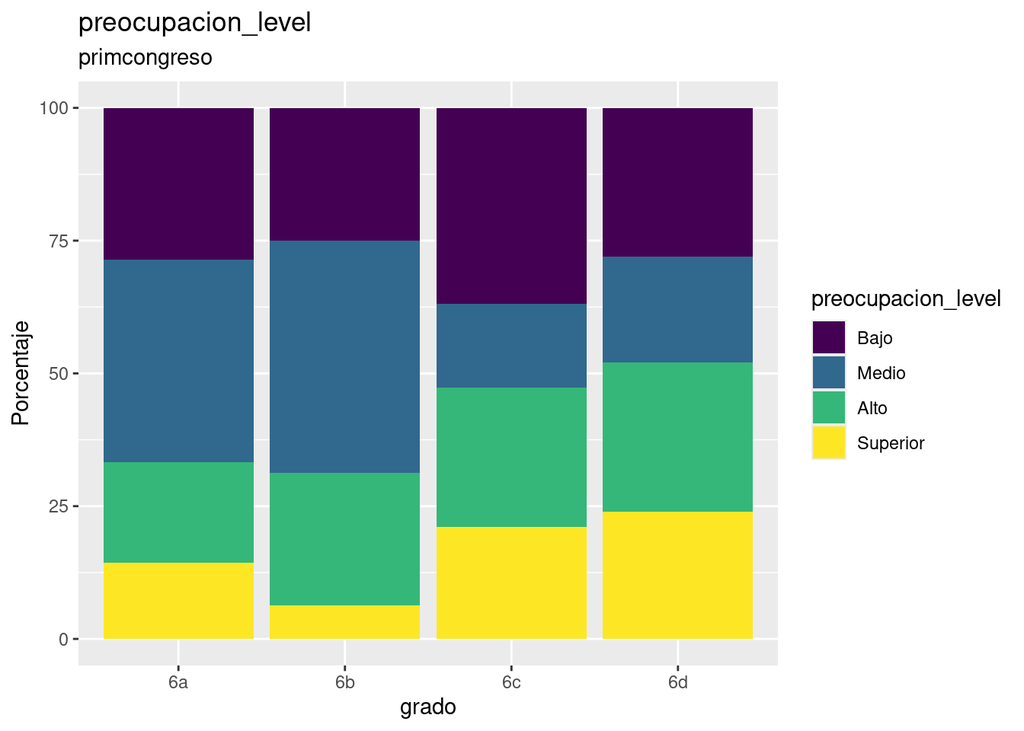

## MEAN AND SD GRAPHS

Showing a main-sd point inverval plot:

- First element is school name same as examples above.
- Second elemnt:

“fG” “Tenaci” “Esfuer” “Preocu”

### Example Augusto Intelligence

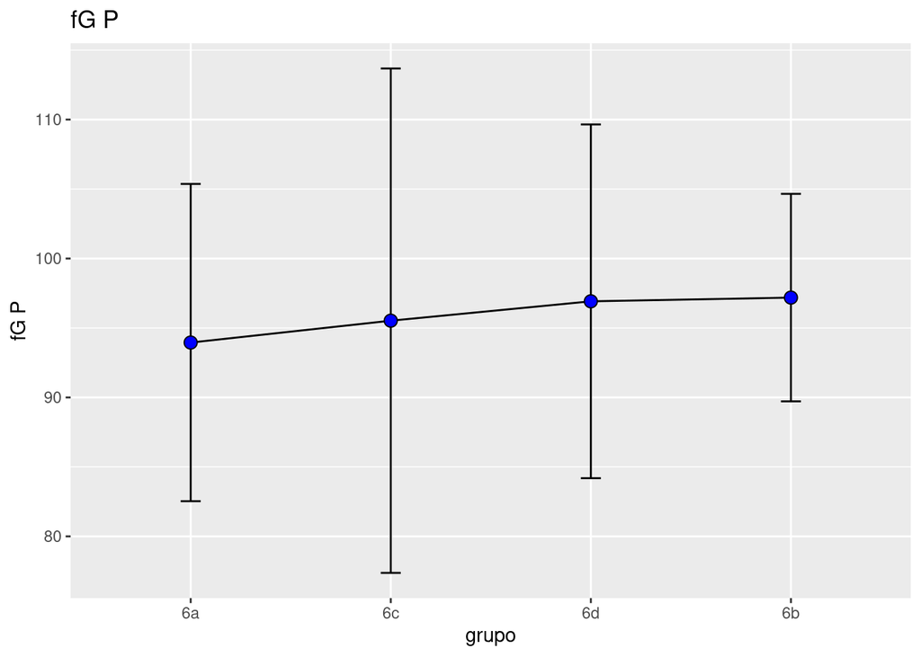

### Example Augusto Tenacidad

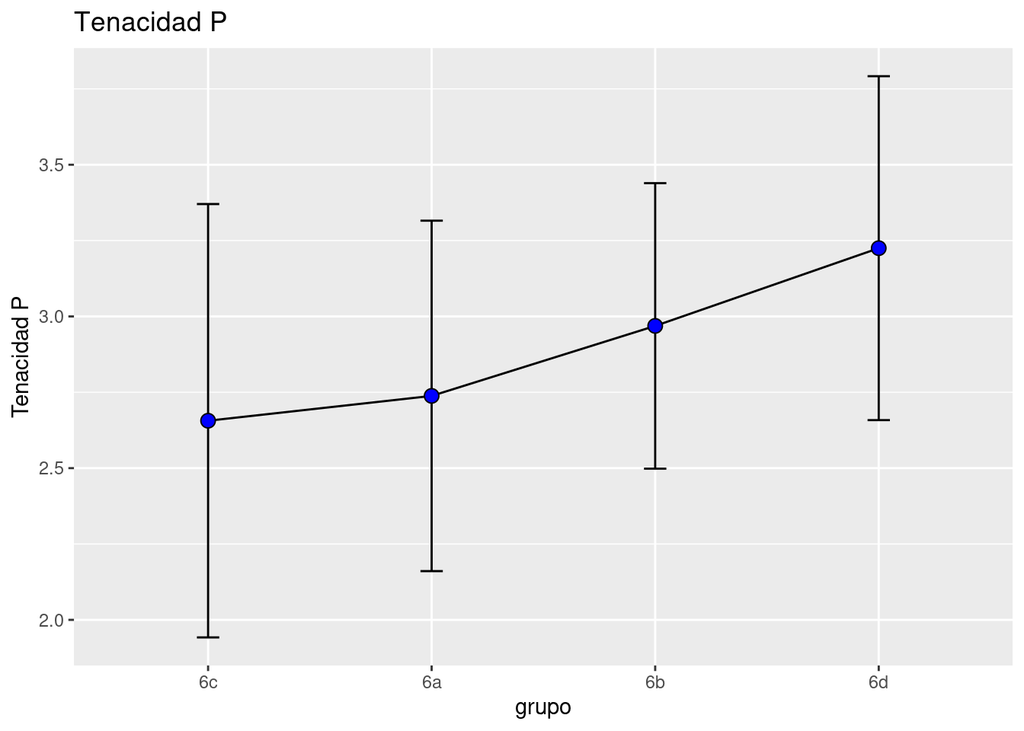